# Analysis of various factors influencing customer ratings for restaurant in respect to Zomato Dataset

## 2.2.4.Understanding the ratings

```python
#to understand the ratings
df3 = df2.groupby(['Aggregate rating','Rating color', 'Rating text']).size().reset_index().rename(columns={0:'Rating Count'})
df3
```

|  | Aggregate rating | Rating color | Rating text | Rating Count |
| --- | --- | --- | --- | --- |
| 0 | 0.0 | White | Not rated | 2148 |
| 1 | 1.8 | Red | Poor | 1 |
| 2 | 1.9 | Red | Poor | 2 |
| 3 | 2.0 | Red | Poor | 7 |
| 4 | 2.1 | Red | Poor | 15 |
| 5 | 2.2 | Red | Poor | 27 |
| 6 | 2.3 | Red | Poor | 47 |
| 7 | 2.4 | Red | Poor | 87 |
| 8 | 2.5 | Orange | Average | 110 |
| 9 | 2.6 | Orange | Average | 191 |
| 10 | 2.7 | Orange | Average | 250 |
| 11 | 2.8 | Orange | Average | 315 |
| 12 | 2.9 | Orange | Average | 381 |
| 13 | 3.0 | Orange | Average | 468 |
| 14 | 3.1 | Orange | Average | 519 |
| 15 | 3.2 | Orange | Average | 522 |
| 16 | 3.3 | Orange | Average | 483 |
| 17 | 3.4 | Orange | Average | 498 |
| 18 | 3.5 | Yellow | Good | 480 |
| 19 | 3.6 | Yellow | Good | 458 |
| 20 | 3.7 | Yellow | Good | 427 |
| 21 | 3.8 | Yellow | Good | 400 |
| 22 | 3.9 | Yellow | Good | 335 |
| 23 | 4.0 | Green | Very Good | 266 |
| 24 | 4.1 | Green | Very Good | 274 |
| 25 | 4.2 | Green | Very Good | 221 |
| 26 | 4.3 | Green | Very Good | 174 |
| 27 | 4.4 | Green | Very Good | 144 |
| 28 | 4.5 | Dark Green | Excellent | 95 |
| 29 | 4.6 | Dark Green | Excellent | 78 |
| 30 | 4.7 | Dark Green | Excellent | 42 |
| 31 | 4.8 | Dark Green | Excellent | 25 |
| 32 | 4.9 | Dark Green | Excellent | 61 |

We can see that restaurants are rated across 6 categories. There are six rating colours used to represent different rating text.

Rating 0 — White — Not rated

Rating 1.8 to 2.4 — Red — Poor

Rating 2.5 to 3.4 — Orange — Average

Rating 3.5 to 3.9 — Yellow — Good

Rating 4.0 to 4.4 — Green — Very Good

Rating 4.5 to 4.9 — Dark Green — Excellent

[output not shown]

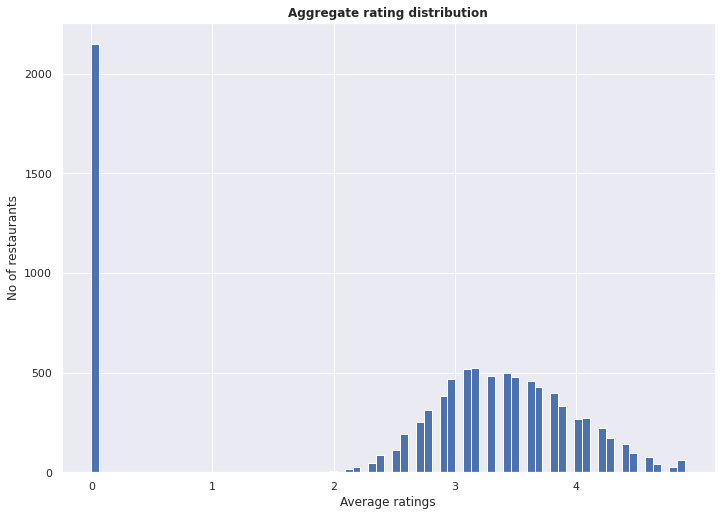

```python
plt.hist(df2['Aggregate rating'],bins=75)
plt.xlabel('Average ratings')
plt.ylabel('No of restaurants')
plt.title('Aggregate rating distribution', weight='bold')
l=[i for i in range(0,5,1)]
plt.xticks(l)
```

## 2.2.5. Top rated restaurants and their Localities

```python
#Top rated restaurants are evaluated by finding the restaurants that have received ratings tags 'excellent, very good and good'. This restaurant are rated greater than 3.4.

df_india = df2.loc[(df2.Country == 'India')]
high_ratings = df_india[df_india['Rating text'].isin(['Excellent','Very Good','Good'])]

high_ratings
```

|  | Restaurant ID | Restaurant Name | Country Code | City | Address | Locality | Locality Verbose | Longitude | Latitude | Cuisines | ... | Has Table booking | Has Online delivery | Is delivering now | Switch to order menu | Price range | Aggregate rating | Rating color | Rating text | Votes | Country |
| --- | --- | --- | --- | --- | --- | --- | --- | --- | --- | --- | --- | --- | --- | --- | --- | --- | --- | --- | --- | --- | --- |
| 624 | 3400025 | Jahanpanah | 1 | Agra | E 23, Shopping Arcade, Sadar Bazaar, Agra Cant... | Agra Cantt | Agra Cantt, Agra | 78.011544 | 27.161661 | North Indian, Mughlai | ... | No | No | No | No | 3 | 3.9 | Yellow | Good | 140 | India |
| 625 | 3400341 | Rangrezz Restaurant | 1 | Agra | E-20, Shopping Arcade, Sadar Bazaar, Agra Cant... | Agra Cantt | Agra Cantt, Agra | 0.000000 | 0.000000 | North Indian, Mughlai | ... | No | No | No | No | 2 | 3.5 | Yellow | Good | 71 | India |
| 626 | 3400005 | Time2Eat - Mama Chicken | 1 | Agra | Main Market, Sadar Bazaar, Agra Cantt, Agra | Agra Cantt | Agra Cantt, Agra | 78.011608 | 27.160832 | North Indian | ... | No | No | No | No | 2 | 3.6 | Yellow | Good | 94 | India |
| 627 | 3400021 | Chokho Jeeman Marwari Jain Bhojanalya | 1 | Agra | 1/48, Delhi Gate, Station Road, Raja Mandi, Ci... | Civil Lines | Civil Lines, Agra | 77.998092 | 27.195928 | Rajasthani | ... | No | No | No | No | 2 | 4.0 | Green | Very Good | 87 | India |
| 628 | 3400017 | Pinch Of Spice | 1 | Agra | 23/453, Opposite Sanjay Cinema, Wazipura Road,... | Civil Lines | Civil Lines, Agra | 78.007553 | 27.201725 | North Indian, Chinese, Mughlai | ... | No | No | No | No | 3 | 4.2 | Green | Very Good | 177 | India |
| ... | ... | ... | ... | ... | ... | ... | ... | ... | ... | ... | ... | ... | ... | ... | ... | ... | ... | ... | ... | ... | ... |
| 9271 | 2800100 | D Cabana | 1 | Vizag | Beach Road, Near Bus Stop, Sagar Nagar, Visakh... | Sagar Nagar | Sagar Nagar, Vizag | 83.361377 | 17.764287 | Continental, Seafood, Chinese, North Indian, B... | ... | No | No | No | No | 2 | 3.6 | Yellow | Good | 193 | India |
| 9272 | 2800418 | Kaloreez | 1 | Vizag | Plot 95, Opposite St. Lukes Nursing School, Da... | Siripuram | Siripuram, Vizag | 0.000000 | 0.000000 | Cafe, North Indian, Chinese | ... | No | No | No | No | 2 | 3.7 | Yellow | Good | 85 | India |
| 9273 | 2800881 | Plot 17 | 1 | Vizag | Plot 17, Gangapur Layout, Siripuram, Vizag | Siripuram | Siripuram, Vizag | 83.315281 | 17.719539 | Burger, Pizza, Biryani | ... | No | No | No | No | 2 | 4.3 | Green | Very Good | 172 | India |
| 9274 | 2800042 | Vista - The Park | 1 | Vizag | The Park, Beach Road, Pedda Waltair, Lawsons B... | The Park, Lawsons Bay | The Park, Lawsons Bay, Vizag | 83.336840 | 17.721182 | American, North Indian, Thai, Continental | ... | No | No | No | No | 4 | 3.8 | Yellow | Good | 74 | India |
| 9275 | 2800019 | Flying Spaghetti Monster | 1 | Vizag | 10-50-12/F2, Sai Dakshata Complex, Beside Leno... | Waltair Uplands | Waltair Uplands, Vizag | 83.314942 | 17.721119 | Italian | ... | No | No | No | No | 3 | 4.4 | Green | Very Good | 316 | India |

2655 rows × 22 columns

```python
top_restaurant=high_ratings['City'].value_counts()[:2655]
```

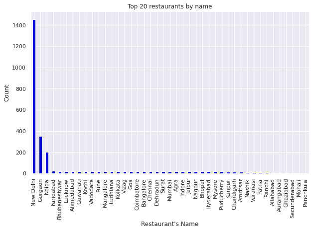

```python
plt.figure(figsize=(10,6))
ax=top_restaurant.plot(kind='bar',color='blue')
plt.title('Top 20 restaurants by name')
plt.xlabel("Restaurant's Name")
plt.ylabel('Count')
plt.show()
```

We will explore the locality of the delhi in depth to find more information on the importance of location.

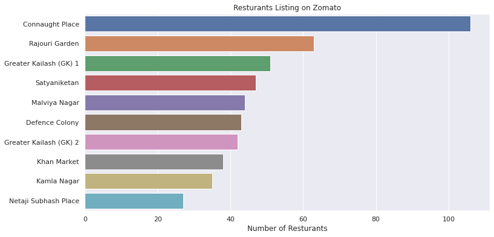

```python
Del = high_ratings[(high_ratings.City == 'New Delhi')]
plt.figure(figsize=(12,6))
sns.barplot(x=Del.Locality.value_counts().head(10), y=Del.Locality.value_counts().head(10).index)

plt.ylabel(None);
plt.xlabel('Number of Resturants')
plt.title('Resturants Listing on Zomato');
```

We can see that upscale areas, such as Connaught Place, Rajouri Garden and GK, have a larger number of top-rated restaurants. We can infer that location is important factor for high ratings.

## 2.2.6. Top 10 Cuisines in overall restaurant listed in dataset and Top rated restaurants

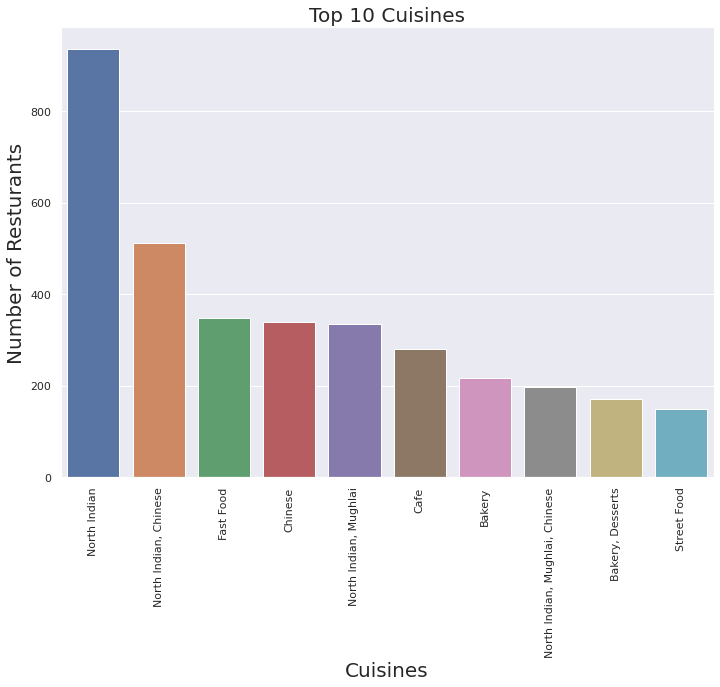

```python
#Top Cuisines among the overall restaurants listed in dataset

Cuisine_data =df_india.groupby(['Cuisines'], as_index=False)['Restaurant ID'].count()
Cuisine_data.columns = ['Cuisines', 'Number of Resturants']
Top15= (Cuisine_data.sort_values(['Number of Resturants'],ascending=False)).head(10)
sns.set(rc={'figure.figsize':(11.7,8.27)})
sns.barplot(Top15['Cuisines'], Top15['Number of Resturants'])
plt.xlabel('Cuisines', fontsize=20)
plt.ylabel('Number of Resturants', fontsize=20)
plt.title('Top 10 Cuisines', fontsize=20)
plt.xticks(rotation = 90)
plt.show()
```

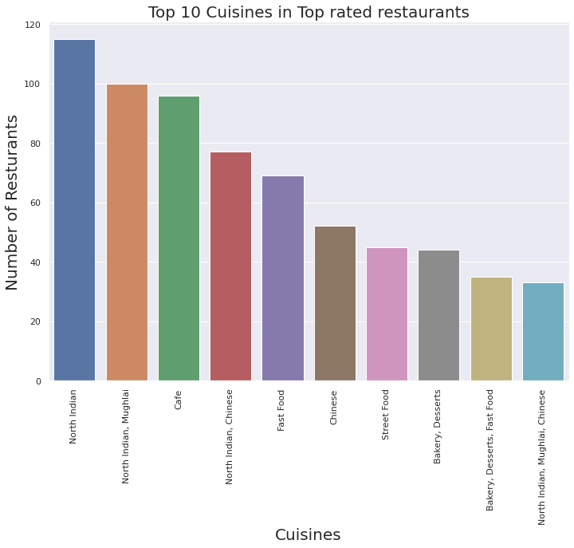

```python
#Top Cuisines among the top rated restaurant
Cuisine_data =high_ratings.groupby(['Cuisines'], as_index=False)['Restaurant ID'].count()
Cuisine_data.columns = ['Cuisines', 'Number of Resturants']
Top15= (Cuisine_data.sort_values(['Number of Resturants'],ascending=False)).head(10)
sns.set(rc={'figure.figsize':(11.7,8.27)})
sns.barplot(Top15['Cuisines'], Top15['Number of Resturants'])
plt.xlabel('Cuisines', fontsize=20)
plt.ylabel('Number of Resturants', fontsize=20)
plt.title('Top 10 Cuisines in Top rated restaurants', fontsize=20)
plt.xticks(rotation = 90)
plt.show()
```

There is a similar pattern of top 10 cuisines in overall dataset and top rated restaurants dataframe. North Indian is the most popular cuisine in both the case. We can analyse that cuisine is important factor to receive high rating.

## 2.2.7 How many restaurant has table booking option?

```python
df_india['Has Table booking'].value_counts
```

```
<bound method IndexOpsMixin.value_counts of 624     No
625     No
626     No
627     No
628     No
        ..
9271    No
9272    No
9273    No
9274    No
9275    No
Name: Has Table booking, Length: 8652, dtype: object>
```

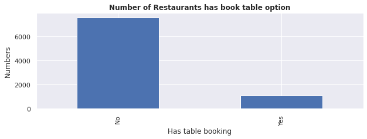

```python
plt.figure(figsize=(10,3))
ax =df_india['Has Table booking'].value_counts().plot(kind='bar')
plt.title('Number of Restaurants has book table option', weight='bold')
plt.xlabel('Has table booking')
plt.ylabel('Numbers')
plt.show()
```

This bar graph vividly shows that more than 6000 restaurants do not allow table booking, whereas less than 2000 restaurants do.

## 2.2.8 Average cost for two

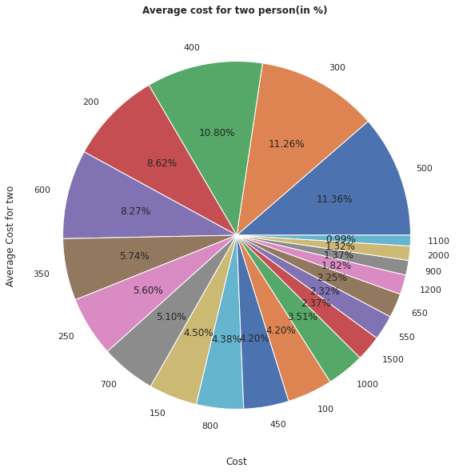

```python
plt.figure(figsize=(15,10))
ax=df_india['Average Cost for two'].value_counts()[:20].plot(kind='pie',autopct='%1.2f%%')
plt.title('Average cost for two person(in %) ', weight='bold')
plt.xlabel('Cost')
plt.show()
```

## 2.2.9. Online delivery distribution of overall restaurant listed in dataset and top rated restaurants

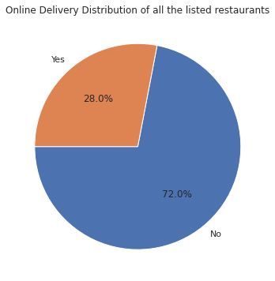

```python
#Online delivery distribution of total restaurant listed in Dataset

plt.figure(figsize=(12,6))
plt.title('Online Delivery Distribution of all the listed restaurants')
plt.pie(df_india['Has Online delivery'].value_counts()/9551*100, labels=df_india['Has Online delivery'].value_counts().index, autopct='%1.1f%%', startangle=180);
```

We can see that only 28% of total restaurant has online delivery

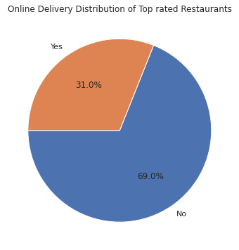

```python
# Online delivery distribution of Top rated restaurant

plt.figure(figsize=(12,6))
plt.title('Online Delivery Distribution of Top rated Restaurants')
plt.pie(high_ratings['Has Online delivery'].value_counts()/9551*100, labels=high_ratings['Has Online delivery'].value_counts().index, autopct='%1.1f%%', startangle=180);
```

We can see that only 31% of total top rated restaurant have online delivery.

Majority of restaurants in India listed in the dataset do not have online delivery service. Even only the 1/3 of the top rated restaurants provide online delivery.

## 2.2.10 . Ratings of restaurant vs cost of two

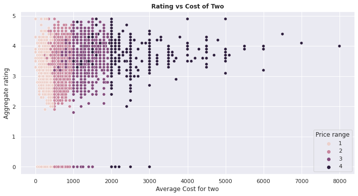

```python
plt.figure(figsize=(12,6))
sns.scatterplot(x="Average Cost for two", y="Aggregate rating", hue='Price range', data=df_india)

plt.xlabel("Average Cost for two")
plt.ylabel("Aggregate rating")
plt.title('Rating vs Cost of Two',weight='bold');
```

According to the scatter plot above, restaurants in the price range of 100 - 2000 have a higher number of ratings, implying that more people dine in this price range. The ratings go all the way up to the 8000 price range. Restaurants with high ratings (such as 4–5) have a wide variety of cost for two people and are scattered throughout the X axis . So, we cannot conclude that there is a positive relationship between aggregate rating and average cost for two.

## 2.2.10 Aggregate Rating vs Table Booking

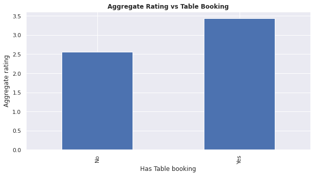

```python
#link - https://www.kaggle.com/vladkrasnikov/eda-zomato-restaurants-data

df.groupby('Has Table booking')['Aggregate rating'].mean().plot(kind='bar', figsize=(10,5))
plt.ylabel('Aggregate rating')
plt.title('Aggregate Rating vs Table Booking',weight='bold');

plt.show();
```

This bar graph clearly shows that restaurants that offer online table booking end up receiving more ratings than those that do not.

## 2.2.11. Aggregate Rating vs Has online delivery

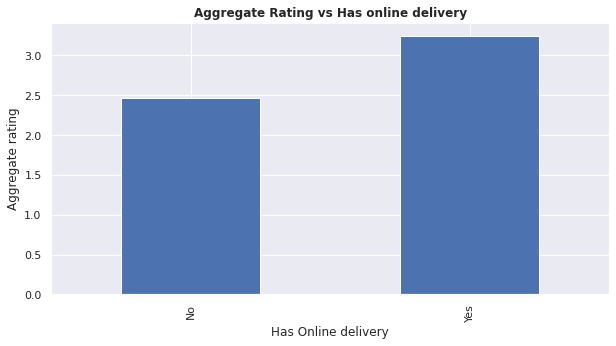

```python
df.groupby('Has Online delivery')['Aggregate rating'].mean().plot(kind='bar', figsize=(10,5))
plt.ylabel('Aggregate rating')
plt.title('Aggregate Rating vs Has online delivery',weight='bold');
plt.show();
```

In the option to order food online, it is observed that the restaurant which has this option is gaining a good number of ratings.

# 2.3 Diagnostic Analytics

Diagnostic analytics is a form of advanced analytics that examines data or content to answer the question, “Why did it happen?” It is characterized by techniques such as drill-down, data discovery, data mining and correlations.Diagnostic Analytics helps us to know why a trend is developed or why a problem occurred. It helps us making inaccurate guesses.

The major factor affecting the ratings of the restaurant are:

# 2.4 Evidence and Hypothesis:

Kivela, Reece, and Inbakaran (1999) studied the difference in the ratings of restaurant attributes based on the demographic characteristics of respondents. In this exhaustive study on restaurants, they divided the restaurants into four categories based on their differentiation in price, location, theme/ambience, service level, cuisine and style. They argued that determinants in restaurant selection vary across age groups, income levels, and restaurant types.

#### 1. H1 - There is a positive relationship between the location of a restaurant and its overall rating.

#### 2. H2 - There is a positive relationship between the cost of food and the overall rating.

#### 3. H3 - There is a positive relationship between cuisines and overall ratings.

#### 4. H4 - There is a positive relationship between food delivery service and overall satisfaction.

```python
#Heatmap

df2.corr()
```

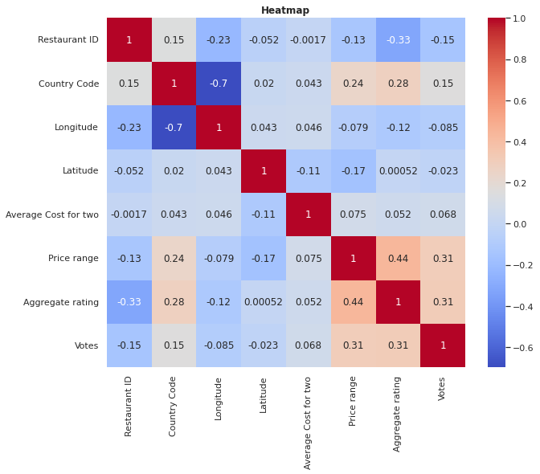

```python
corrmat = df2.corr()
plt.figure(figsize=(10,8))
plt.title('Heatmap',weight='bold');
sns.heatmap(corrmat,annot = True, cmap= 'coolwarm')
```

### 2.4.1 Analysis

```python
df['Has Table booking'].replace({'Yes':1,'No':0},inplace=True)
df['Has Online delivery'].replace({'Yes':1,'No':0},inplace=True)
df['Switch to order menu'].replace({'Yes':1,'No':0},inplace=True)
df.head()
```

|  | Restaurant ID | Restaurant Name | Country Code | City | Address | Locality | Locality Verbose | Longitude | Latitude | Cuisines | ... | Currency | Has Table booking | Has Online delivery | Is delivering now | Switch to order menu | Price range | Aggregate rating | Rating color | Rating text | Votes |
| --- | --- | --- | --- | --- | --- | --- | --- | --- | --- | --- | --- | --- | --- | --- | --- | --- | --- | --- | --- | --- | --- |
| 0 | 6317637 | Le Petit Souffle | 162 | Makati City | Third Floor, Century City Mall, Kalayaan Avenu... | Century City Mall, Poblacion, Makati City | Century City Mall, Poblacion, Makati City, Mak... | 121.027535 | 14.565443 | French, Japanese, Desserts | ... | Botswana Pula(P) | 1 | 0 | No | 0 | 3 | 4.8 | Dark Green | Excellent | 314 |
| 1 | 6304287 | Izakaya Kikufuji | 162 | Makati City | Little Tokyo, 2277 Chino Roces Avenue, Legaspi... | Little Tokyo, Legaspi Village, Makati City | Little Tokyo, Legaspi Village, Makati City, Ma... | 121.014101 | 14.553708 | Japanese | ... | Botswana Pula(P) | 1 | 0 | No | 0 | 3 | 4.5 | Dark Green | Excellent | 591 |
| 2 | 6300002 | Heat - Edsa Shangri-La | 162 | Mandaluyong City | Edsa Shangri-La, 1 Garden Way, Ortigas, Mandal... | Edsa Shangri-La, Ortigas, Mandaluyong City | Edsa Shangri-La, Ortigas, Mandaluyong City, Ma... | 121.056831 | 14.581404 | Seafood, Asian, Filipino, Indian | ... | Botswana Pula(P) | 1 | 0 | No | 0 | 4 | 4.4 | Green | Very Good | 270 |
| 3 | 6318506 | Ooma | 162 | Mandaluyong City | Third Floor, Mega Fashion Hall, SM Megamall, O... | SM Megamall, Ortigas, Mandaluyong City | SM Megamall, Ortigas, Mandaluyong City, Mandal... | 121.056475 | 14.585318 | Japanese, Sushi | ... | Botswana Pula(P) | 0 | 0 | No | 0 | 4 | 4.9 | Dark Green | Excellent | 365 |
| 4 | 6314302 | Sambo Kojin | 162 | Mandaluyong City | Third Floor, Mega Atrium, SM Megamall, Ortigas... | SM Megamall, Ortigas, Mandaluyong City | SM Megamall, Ortigas, Mandaluyong City, Mandal... | 121.057508 | 14.584450 | Japanese, Korean | ... | Botswana Pula(P) | 1 | 0 | No | 0 | 4 | 4.8 | Dark Green | Excellent | 229 |

5 rows × 21 columns

```python
cuisines = list(set(df_india['Cuisines'].str.cat(sep=',').replace(" ","").split(',')))
cuisines.sort()
cuisines
```

```
['Afghani',
 'African',
 'American',
 'Andhra',
 'Arabian',
 'Armenian',
 'Asian',
 'Assamese',
 'Awadhi',
 'BBQ',
 'Bakery',
 'Belgian',
 'Bengali',
 'Beverages',
 'Bihari',
 'Biryani',
 'British',
 'Burger',
 'Burmese',
 'Cafe',
 'Cajun',
 'CharcoalGrill',
 'Chettinad',
 'Chinese',
 'Continental',
 'CuisineVaries',
 'Deli',
 'Desserts',
 'DrinksOnly',
 'European',
 'FastFood',
 'FingerFood',
 'French',
 'German',
 'Goan',
 'Greek',
 'Gujarati',
 'HealthyFood',
 'Hyderabadi',
 'IceCream',
```

[output cut: 35 more lines]

```
 'Sandwich',
 'Seafood',
 'SouthAmerican',
 'SouthIndian',
 'Spanish',
 'SriLankan',
 'Steak',
 'StreetFood',
 'Sushi',
 'Tea',
 'Tex-Mex',
 'Thai',
 'Tibetan',
 'Turkish',
 'Vietnamese']
```

```python
for cuisine in cuisines:
    df_india[cuisine] = df_india['Cuisines'].str.contains(cuisine)
    df_india[cuisine].replace({True:1,False:0},inplace=True)
df_india.head()
```

|  | Restaurant ID | Restaurant Name | Country Code | City | Address | Locality | Locality Verbose | Longitude | Latitude | Cuisines | ... | SriLankan | Steak | StreetFood | Sushi | Tea | Tex-Mex | Thai | Tibetan | Turkish | Vietnamese |
| --- | --- | --- | --- | --- | --- | --- | --- | --- | --- | --- | --- | --- | --- | --- | --- | --- | --- | --- | --- | --- | --- |
| 624 | 3400025 | Jahanpanah | 1 | Agra | E 23, Shopping Arcade, Sadar Bazaar, Agra Cant... | Agra Cantt | Agra Cantt, Agra | 78.011544 | 27.161661 | North Indian, Mughlai | ... | 0 | 0 | 0 | 0 | 0 | 0 | 0 | 0 | 0 | 0 |
| 625 | 3400341 | Rangrezz Restaurant | 1 | Agra | E-20, Shopping Arcade, Sadar Bazaar, Agra Cant... | Agra Cantt | Agra Cantt, Agra | 0.000000 | 0.000000 | North Indian, Mughlai | ... | 0 | 0 | 0 | 0 | 0 | 0 | 0 | 0 | 0 | 0 |
| 626 | 3400005 | Time2Eat - Mama Chicken | 1 | Agra | Main Market, Sadar Bazaar, Agra Cantt, Agra | Agra Cantt | Agra Cantt, Agra | 78.011608 | 27.160832 | North Indian | ... | 0 | 0 | 0 | 0 | 0 | 0 | 0 | 0 | 0 | 0 |
| 627 | 3400021 | Chokho Jeeman Marwari Jain Bhojanalya | 1 | Agra | 1/48, Delhi Gate, Station Road, Raja Mandi, Ci... | Civil Lines | Civil Lines, Agra | 77.998092 | 27.195928 | Rajasthani | ... | 0 | 0 | 0 | 0 | 0 | 0 | 0 | 0 | 0 | 0 |
| 628 | 3400017 | Pinch Of Spice | 1 | Agra | 23/453, Opposite Sanjay Cinema, Wazipura Road,... | Civil Lines | Civil Lines, Agra | 78.007553 | 27.201725 | North Indian, Chinese, Mughlai | ... | 0 | 0 | 0 | 0 | 0 | 0 | 0 | 0 | 0 | 0 |

5 rows × 112 columns

```python
df3 = df[['Price range','Has Table booking','Aggregate rating','Votes','Has Online delivery','Average Cost for two']]
df3.head()
```

|  | Price range | Has Table booking | Aggregate rating | Votes | Has Online delivery | Average Cost for two |
| --- | --- | --- | --- | --- | --- | --- |
| 0 | 3 | 1 | 4.8 | 314 | 0 | 1100 |
| 1 | 3 | 1 | 4.5 | 591 | 0 | 1200 |
| 2 | 4 | 1 | 4.4 | 270 | 0 | 4000 |
| 3 | 4 | 0 | 4.9 | 365 | 0 | 1500 |
| 4 | 4 | 1 | 4.8 | 229 | 0 | 1500 |

```python
from sklearn.preprocessing import MinMaxScaler

scaler = MinMaxScaler()
scaler.fit(df3)
df3 = pd.DataFrame(scaler.transform(df3),columns=df3.columns)
df3.head()
```

|  | Price range | Has Table booking | Aggregate rating | Votes | Has Online delivery | Average Cost for two |
| --- | --- | --- | --- | --- | --- | --- |
| 0 | 0.666667 | 1.0 | 0.979592 | 0.028718 | 0.0 | 0.001375 |
| 1 | 0.666667 | 1.0 | 0.918367 | 0.054052 | 0.0 | 0.001500 |
| 2 | 1.000000 | 1.0 | 0.897959 | 0.024694 | 0.0 | 0.005000 |
| 3 | 1.000000 | 0.0 | 1.000000 | 0.033382 | 0.0 | 0.001875 |
| 4 | 1.000000 | 1.0 | 0.979592 | 0.020944 | 0.0 | 0.001875 |

```python
from sklearn.model_selection import train_test_split

train,test = train_test_split(df3,random_state=50)
X_train = train.iloc[:,df3.columns!='Average Cost for two']
X_test = test.iloc[:,df3.columns!='Average Cost for two']
y_train = train['Average Cost for two']
y_test = test['Average Cost for two']
print('Training set size - ' , X_train.shape)
print('Testing set size - ' , X_test.shape)
```

```
Training set size -  (7163, 5)
Testing set size -  (2388, 5)
```

```python
from sklearn.linear_model import LinearRegression
from sklearn.metrics import r2_score

reg = LinearRegression()
reg.fit(X_train, y_train)
y_pred = reg.predict(X_test)
score = r2_score(y_test,y_pred)
score
```

```
0.0010435502524822615
```

#### R-squared (R2) is a statistical measure that represents the proportion of the variance for a dependent variable that's explained by an independent variable or variables in a regression model.

The value of R square is 0.001 in the given analysis, which is below standard. As a result, we can infer that this regression module isn't appropriate for the data.

# 3 Conclusion

# 3.1 Summary of the Findings

1. India has the highest number of restaurants listed in Zomato. Delhi is the largest city with the maximum number of restaurants listed in the dataset.
2. North Indian is the most demanded cuisines
3. Majority of Indian restaurants have price range between 0-750 and 750- 1500.
4. Majority of restaurants do not have online delivery service
5. Average cost for two people is under Rs.2000

# 3.2 Business Implication for Audience

# 3.3 Limitation of the project

The dataset posed the followed limitations:

- The data within the variable within this data set is categorical and not numerical. Thus, using regression analysis is difficult to conduct.
- Large number of restaurant were not rated
- The dataset was restricted to cuisines only. It lacked the information for dishes in the cuisines

# 3.4 Potential Project

Our analysis will assist not only restaurants, but also organizations looking to invest in the restaurant or cloud kitchen industry. This analysis will produce the best results, upon which the rating elements will be based. The analysis will assist you with several elements such as location, cuisines, delivery, online booking, pricing range, and cost for two people. And also to get accurate result Machine Learning with model processing can be helpful.

# Reference

https://blog.jovian.ai/explanatory-data-analysis-of-zomato-restaurant-data-71ba8c3c7e5e

https://www.kaggle.com/vladkrasnikov/eda-zomato-restaurants-data

https://www.kaggle.com/abkuril/eda-on-zomato-restaurants-data-with-deep-insights

https://www.kaggle.com/mykytarepnin/eda-zomato-restaurants-data

https://www.kaggle.com/akshat0007/applying-knn-for-regression-on-zomato-dataset#1.-A-bar-graph-presentation-which-shows-how-many-restaurants----provide-Online-Delivery

https://www.investopedia.com/terms/r/r-squared.asp

https://www.kaggle.com/aninditapani/cost-for-two-please-regression

https://www.researchgate.net/publication/350854655_A_Study_of_various_factors_which_influence_in_decision_making_of_customer_impact_of_word_of_mouth_Marketing_with_respect_to_restaurants